# Aula 1 - Introdução à Modelagem Estatística

Profa Luciana C. Alves

2026-03-03

### **DEFINIÇÃO DE ESTATÍSTICA APLICADA ÀS CIÊNCIAS SOCIAIS**

### Estatística para Ciências Sociais é a estatística aplicada ao estudo do comportamento humano e da natureza da realidade social.

### **MAIS DEFINIÇÕES IMPORTANTES**

**População:** totalidade dos elementos ou de um atributo dos elementos referentes a um conjunto determinado.

**Elementos:** são unidades de análise ou unidades de observação; podem ser pessoas, domicílios, escolas, hospitais, creches etc.

**Amostra:** é uma parte da população de estudo.

**Parâmetro:** é quantidade fixa de uma população.

Ex: Idade média dos alunos da graduação do IFCH, Proporção de pessoas que residem em áreas de  
vulnerabilidade, etc.

**Estimador:** é uma característica numérica estabelecida para uma amostra.

Ex: Idade média dos alunos dos alunos que estão cursando HZ631 no IFCH.

**EXEMPLO: Mercado de Trabalho no Brasil**

**População:** conjunto de todos os idosos brasileiros.

**Parâmetro:** proporção de idosos que estão no mercado de trabalho no Brasil.

**Amostra:** subgrupo de idosos selecionados em todo o país.

**Estimador:** proporção de idosos que estão no mercado de trabalho na amostra.

## **TIPOS DE FONTES DE DADOS**

**Dados primários:** dados resultantes de um estudo realizado pelo pesquisador e sua equipe (pesquisador coleta o seu próprio dado).

**Dados secundários:** dados obtidos por meio dos institutos de pesquisa como o IBGE, de organizações governamentais como o Datasus, Fundação Seade, dados da OMS, OPAS, de registros como Registro Civil etc.

## **CONCEITO DE VARIÁVEL**

**Variável:** é uma característica observada, que recebe valores diferentes para pessoas, lugares ou coisas diferentes.

Ex: altura das mulheres brasileiras, idade dos alunos da disciplina de estatística aplicada à ciências sociais, sexo, estado civil, cor da pele, escolaridade, renda, PIB, IDH, índice de vulnerabilidade.

**Variável dependente ou resposta:** todo efeito, resposta ou resultado que pode estar influenciado ou depender de um ou mais fatores (variáveis independentes ou explicativas).

**Variáveis independentes ou explicativas:** todo fator, característica, tratamento ou exposição, tanto ambiental como pessoal, que pode desenvolver um efeito ou ter influência sobre um ou mais aspectos (variável dependente).

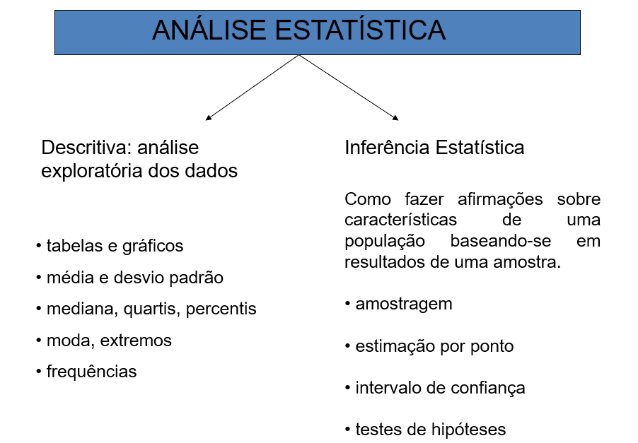

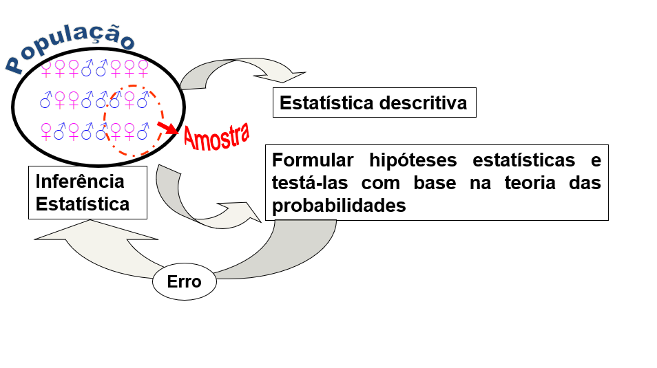

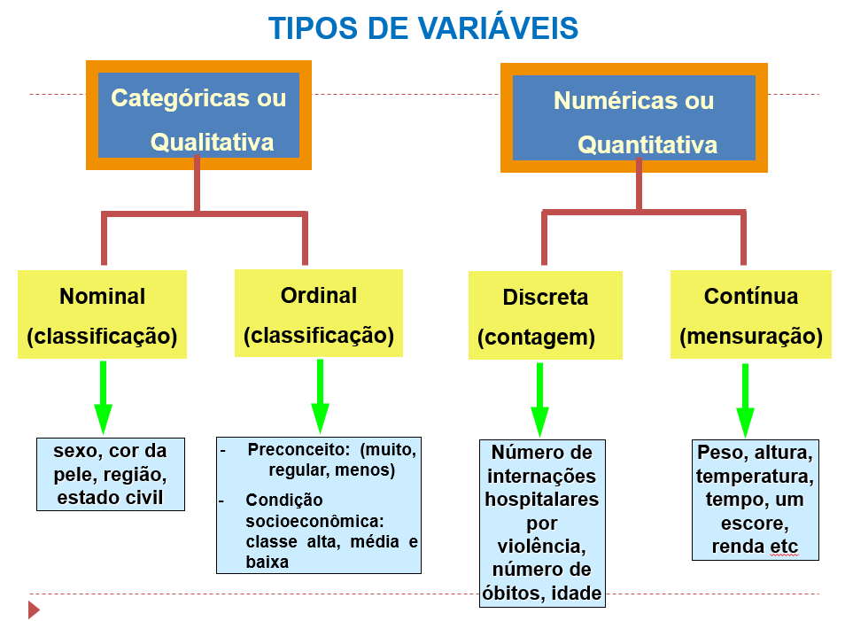

## **MODELAGEM ESTATÍSTICA OU ANÁLISE DE REGRESSÃO**

O principal objetivo dos modelos de regressão é “modelar” o relacionamento entre diversas variáveis explicativas (independentes-X) e uma variável resposta (dependente-Y).

Este relacionamento pode ser por uma função linear ou uma função não linear.

- Direção e a força da associação.
- Determinar quais das variáveis independentes são importantes na predição da variável dependente
- Descrever relação simultânea entre um conjunto de variáveis explicativas (independentes) e a variável  
  resposta (dependente).

# **Exemplos**

1. Modelo: regressão linear. Y: salário. X: anos de estudo, experiência. Área: Economia do Trabalho.
2. Modelo: regressão linear. Y: notas ou desempenho escolar. X: escolaridade dos pais, capital cultural. Área: Sociologia da Educação.
3. Crescimento econômico entre países. Y: taxa de crescimento do PIB. X: capital humano, investimento, instabilidade política. Área: Economia Política.
4. Mortalidade Infantil e Desigualdade. Y: taxa de mortalidade infantil. X: renda média municipal, saneamento, escolaridade feminina. Área: Demografia / Saúde Pública.
5. Participação Política. Y: índice de confiança nas instituições. X: renda, escolaridade, idade. Área: Ciência Política.
6. Participação Eleitoral. Y: votou (1) / não votou (0). X: renda, educação, mobilização política. Área: Ciência Política.
7. Probabilidade de Pobreza. Estudos usando microdados da Pesquisa Nacional por Amostra de Domicílios (PNAD). Y: abaixo da linha de pobreza (sim/não). X: escolaridade, cor/raça, sexo, região. Área: Sociologia / Economia.
8. Inserção no Mercado de Trabalho. Y: empregado (1) / desempregado (0). X: escolaridade, gênero, imigração. Área: Economia do Trabalho.
9. Pesquisas com dados da Pesquisa Nacional de Demografia e Saúde (PNDS). Y: uso de contraceptivo (sim/não). X: escolaridade, número de filhos, área urbana/rural. Área: Demografia.
10. Criminalidade. Estudos com dados do Fórum Brasileiro de Segurança Pública. Y: reincidência criminal (sim/não). X: idade, escolaridade, histórico criminal. Área: Sociologia.
11. Apoio a Políticas Públicas. Y: apoia política X (sim/não). X: ideologia, renda, religião. Área: Sociologia Política.

# Modelagem

Conhecidos um conjunto de valores da variável explicativa e os valores associados da variável resposta, determinamos os parâmetros da equação.

Testa-se em seguida a adequação dessa equação, isto é, se o modelo fornecido pela equação descreve bem as observações.

Pode-se então concluir pela adequação do modelo e adotá-lo ou concluir que ele não é satisfatório e testar outro, voltando à etapa inicial e repetindo todo o processo.

Obtida uma equação razoável, podemos utilizá-la para resolver os problemas: predição do valor da variável resposta, verificação.

## FAMILIARIZANDO COM O R

[figure not shown]